# geomorph_final

Allison Davis Connelly & Jackson Horvath

2025-11-12

# **PURPOSE**

There are two main goals of this analysis. First, we want to compare morphological variation among the asexual Amazon molly and their two parental species (sailfin and Atlantic molly) across their native and introduced geographic range PART 1. Second, we want to compare the precision between the two data collection methods used (manual measurements versus digital geomorphometrics) PART 2.

# **PART I: VARIATION**

The following analyses will compare variation among the species.

## **Data**

Original TPS files were imported into MorphoJ where we performed a procrustes analysis and a multivariate regression on shape (procrustes coordinates) and size (centroid size) to correct for overall body size differences between the species. We then imported the residuals of this regression below to perform our analyses.

All analyses were conducted using R version 4.4.2

### Load required libraries

Remove the ‘#’ in the code below if it is the first time installing library.

```r
#install.packages("curl")             #v5.2.1
library(curl)
#install.packages("dplyr")            #v1.1.4
library(dplyr)
#install.packages("tidyverse")        #v2.0.0
library(tidyverse)
#install.packages("tidyr")            #v1.3.1
library(tidyr)

#install.packages("gt")               #v0.11.1
library(gt)
#install.packages("factoextra")       #v1.0.7
library(factoextra)
#install.packages("car")              #v3.1-2
library(car)
#install.packages("AMR")              #v2.1.1 DOUBLE CHECK I NEED ALL OF THE FOLLOWING 4
library(AMR)
```

```r
#install.packages("ggplot2")          #v3.5.1
library(ggplot2)

#install.packages("ggfortify")        #v0.4.17
library(ggfortify)
#install.packages("ggbiplot")         #v0.6.2
library(ggbiplot)
#install.packages("gridExtra")        #v2.3
library(gridExtra)
#install.packages("blandr")           #v0.6.0
library(blandr)
#install.packages("stringr")          #v1.5.1
library(stringr)
```

### Read in data

```r
test.df <- curl("https://raw.githubusercontent.com/allisondavis/morphology_analysis/refs/heads/master/MV%20regression%2C%20results.txt")

test.df <- read.table(test.df, header = TRUE, sep = "\t")

# Replace HydroBASIN basin codes with basin names
test.df$Basin <- factor(test.df$Basin,
                        levels = c("7040048420", "7040049270", "7040048310", "7040049990", "7040049280"),
                        labels = c("Nueces-Rio Grande Coastal", "Rio Grande", "Brazos-Colorado Coastal", "Panuco", "San Fernando-Soto la Marina"))

# Replace default residual column names with the corresponding landmark (x,y). This will make it easier to interpret which size-corrected shape coordinates influence our results later on.

n_landmarks <- 16

coord_names <- as.vector(rbind(
  paste0("LM", 1:n_landmarks, ".X"),
  paste0("LM", 1:n_landmarks, ".Y")
))

colnames(test.df)[7:(6 + length(coord_names))] <- coord_names
```

## **Analysis**

### *PCA*

We’ll create a PCA to visualize overall shape differences. We’ll then perform Levene’s tests on the PC scores to assess differences in variation among the species.

#### Loadings

```r
PCA.test <- prcomp(test.df[, 7:38], center = TRUE, scale. = FALSE)
#NOTE: scale=false uses covariance matrix like in MorphoJ (what we imported); scale=true only useful if variables are measured on different scales

summary(PCA.test)
```

```
## Importance of components:
##                            PC1     PC2     PC3     PC4     PC5     PC6      PC7
## Standard deviation     0.02836 0.01986 0.01969 0.01378 0.01248 0.01121 0.009914
## Proportion of Variance 0.30299 0.14861 0.14601 0.07156 0.05867 0.04729 0.037020
## Cumulative Proportion  0.30299 0.45160 0.59760 0.66916 0.72783 0.77512 0.812150
##                             PC8      PC9    PC10    PC11     PC12     PC13
## Standard deviation     0.008759 0.008336 0.00762 0.00651 0.006144 0.005412
## Proportion of Variance 0.028900 0.026170 0.02187 0.01596 0.014220 0.011030
## Cumulative Proportion  0.841040 0.867210 0.88908 0.90504 0.919260 0.930290
##                            PC14     PC15     PC16     PC17     PC18     PC19
## Standard deviation     0.005218 0.005002 0.004721 0.004455 0.003892 0.003739
## Proportion of Variance 0.010260 0.009420 0.008390 0.007470 0.005710 0.005270
## Cumulative Proportion  0.940550 0.949980 0.958370 0.965850 0.971550 0.976820
##                           PC20     PC21    PC22     PC23     PC24     PC25
## Standard deviation     0.00333 0.003231 0.00321 0.002557 0.002468 0.002408
## Proportion of Variance 0.00418 0.003930 0.00388 0.002460 0.002290 0.002180
## Cumulative Proportion  0.98099 0.984930 0.98881 0.991270 0.993560 0.995750
##                            PC26     PC27    PC28      PC29      PC30     PC31
## Standard deviation     0.002136 0.002034 0.00161 2.896e-16 2.126e-16 2.73e-17
## Proportion of Variance 0.001720 0.001560 0.00098 0.000e+00 0.000e+00 0.00e+00
## Cumulative Proportion  0.997470 0.999020 1.00000 1.000e+00 1.000e+00 1.00e+00
##                             PC32
## Standard deviation     1.825e-17
## Proportion of Variance 0.000e+00
## Cumulative Proportion  1.000e+00
```

```r
(eig.val.test <- get_eigenvalue(PCA.test))
```

```
##          eigenvalue variance.percent cumulative.variance.percent
## Dim.1  8.044309e-04     3.029912e+01                    30.29912
## Dim.2  3.945433e-04     1.486058e+01                    45.15971
## Dim.3  3.876418e-04     1.460064e+01                    59.76035
## Dim.4  1.899869e-04     7.155909e+00                    66.91626
## Dim.5  1.557587e-04     5.866694e+00                    72.78295
## Dim.6  1.255665e-04     4.729499e+00                    77.51245
## Dim.7  9.829059e-05     3.702143e+00                    81.21459
## Dim.8  7.672005e-05     2.889683e+00                    84.10427
## Dim.9  6.948059e-05     2.617006e+00                    86.72128
## Dim.10 5.806752e-05     2.187130e+00                    88.90841
## Dim.11 4.237375e-05     1.596019e+00                    90.50443
## Dim.12 3.775063e-05     1.421888e+00                    91.92632
## Dim.13 2.928853e-05     1.103161e+00                    93.02948
## Dim.14 2.723190e-05     1.025697e+00                    94.05518
## Dim.15 2.502220e-05     9.424683e-01                    94.99764
## Dim.16 2.228727e-05     8.394564e-01                    95.83710
## Dim.17 1.984478e-05     7.474592e-01                    96.58456
## Dim.18 1.514869e-05     5.705797e-01                    97.15514
## Dim.19 1.398100e-05     5.265985e-01                    97.68174
## Dim.20 1.108613e-05     4.175621e-01                    98.09930
## Dim.21 1.044038e-05     3.932397e-01                    98.49254
## Dim.22 1.030651e-05     3.881977e-01                    98.88074
## Dim.23 6.537065e-06     2.462204e-01                    99.12696
## Dim.24 6.089258e-06     2.293536e-01                    99.35631
## Dim.25 5.797141e-06     2.183509e-01                    99.57466
## Dim.26 4.563074e-06     1.718695e-01                    99.74653
## Dim.27 4.138116e-06     1.558633e-01                    99.90240
## Dim.28 2.591368e-06     9.760463e-02                   100.00000
## Dim.29 8.389200e-32     3.159816e-27                   100.00000
## Dim.30 4.520650e-32     1.702716e-27                   100.00000
## Dim.31 7.455525e-34     2.808145e-29                   100.00000
## Dim.32 3.331721e-34     1.254902e-29                   100.00000
```

```r
# the first 2 dimensions account for nearly half of the variation (45.2%). We will extract the individual scores for the first 2 dimensions and attach it to the original data frame.

ind.test <- get_pca_ind(PCA.test)
head(ind.test$coord[,1:2])
```

```
##         Dim.1         Dim.2
## 1  0.01340669  0.0078857358
## 2  0.01342228 -0.0223168798
## 3 -0.02748104 -0.0096209523
## 4 -0.02001009  0.0003470414
## 5 -0.03116908  0.0111344766
## 6 -0.01375579  0.0166512862
```

```r
test.df <- cbind(test.df, ind.test$coord[,1:2])


# Will investigate the influence of each landmark coordinates on the first 2 dimensions
(loadings <- PCA.test$rotation[, 1:2])
```

```
##                 PC1          PC2
## LM1.X   0.135008248 -0.110107210
## LM1.Y   0.155310001 -0.133546894
## LM2.X   0.263422372  0.006700256
## LM2.Y   0.148360094  0.156240124
## LM3.X  -0.670432329 -0.505275356
## LM3.Y   0.174401325  0.117100951
## LM4.X   0.205954566  0.026521398
## LM4.Y   0.029040819 -0.029517028
## LM5.X  -0.079230864  0.183352491
## LM5.Y   0.100564008  0.002877471
## LM6.X  -0.105055841  0.247292942
## LM6.Y   0.059706631 -0.090181853
## LM7.X  -0.042277217  0.087980640
## LM7.Y   0.005249607 -0.188157464
## LM8.X   0.143634501 -0.185964018
## LM8.Y  -0.072327608 -0.031638025
## LM9.X   0.188160260 -0.387448897
## LM9.Y  -0.158585258  0.035307617
## LM10.X -0.003795688 -0.134926056
## LM10.Y -0.363086378  0.352140160
## LM11.X -0.145276979  0.213625337
## LM11.Y -0.044727402  0.001069053
## LM12.X -0.030163021  0.231249783
## LM12.Y -0.011025942 -0.098728303
## LM13.X  0.023045499  0.169496081
## LM13.Y -0.122714633  0.038725202
## LM14.X -0.038783243  0.209659503
## LM14.Y -0.119849240  0.035390979
## LM15.X  0.074531941 -0.035206773
## LM15.Y  0.118234295 -0.083421229
## LM16.X  0.081257793 -0.016950123
## LM16.Y  0.101449680 -0.083660762
```

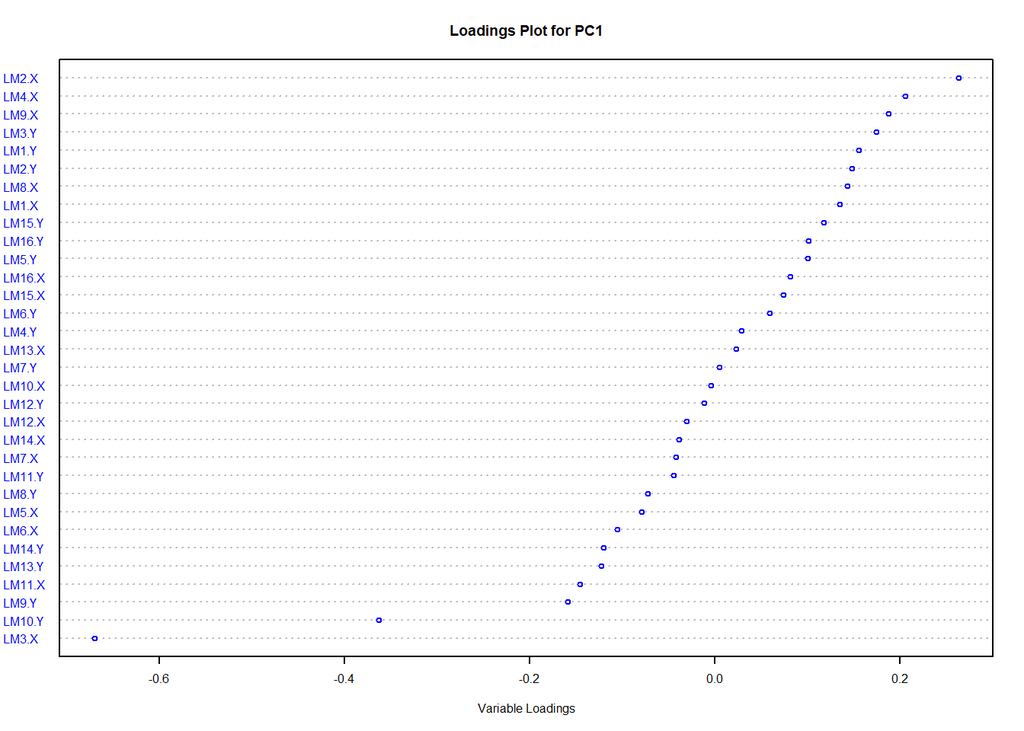

```r
sorted.loadings.1 <- loadings[order(loadings[, 1]), 1]
myTitle <- "Loadings Plot for PC1"
myXlab  <- "Variable Loadings"
dotchart(sorted.loadings.1, main=myTitle, xlab=myXlab, cex=0.5, col="blue")
```

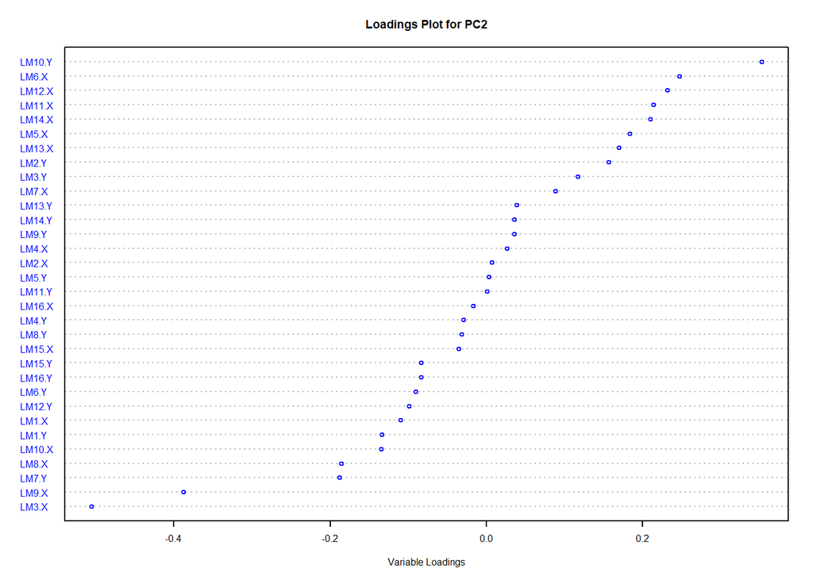

```r
sorted.loadings.2 <- loadings[order(loadings[, 2]), 2]
myTitle <- "Loadings Plot for PC2"
myXlab  <- "Variable Loadings"
dotchart(sorted.loadings.2, main=myTitle, xlab=myXlab, cex=0.5, col="blue")
```